# Copy of DS project Final

Team: Kerui Geng (Graduate student)

Project: Predicting consumers' following number of purchases based on their reviews and item characteristics

Github link: https://keruigeng.github.io (This link is a link to the github.io site); https://github.com/keruigeng/keruigeng.github.io/tree/master (This link is a link where you can find all the data, data are in the master branch)

## **Introduction**

My plan is to use the combined dataset to predict consumers' future purchasing quantity based on their one-time purchase information. To achieve this, I take four main steps:

1. I combine product-level datasets from amazon with manufacturer datasets from People Data Lab.
2. I cleaned the previous combined data. To get the numerical aspect of the item characteristic, I subtract numerical information from string variables and split the category-subcategory variable into a set of categorical variables.
3. I analyze the data and find out the correlation between item characteristics and consumer's review rating with future purchasing quantiles. I also plot the consumer's future purchasing quantiles versus some item characteristics and consumer's review rating to explore their non-linear relationship.
4. I train a linear regression to explore whether consumer review can predict future purchasing quantiles. I also train a K-nearest neighborhood model and look at their test performance with consumer's review and without consumer's review indicators. To better predict the consumers' following number of purchases, I choose the random forest model as my prediction model and predict the future purchasing quantities bought.

In marketing, a good shopping experience here, measured based on a consumer's review rating, would boost consumers' trust in the seller, thus stimulating more purchases. In economics, some products are complementary, meaning consumers gain more utility if they consume several products together. Therefore, some item characteristics might predict the consumers' following purchasing quantity. In sum, my project mainly deals with those two questions:

- (1): Do consumer's review ratings predict their following purchasing quantity?
- (2): Can consumer's review rating and item characteristics predict consumers' following number of purchases well?

Hopefully, this project shield light on the importance of consumer review in predicting their future purchasing quantities. In addition, this project tries to create a system that can help online sellers predict consumers' future purchasing quantities. Understanding consumers' future purchasing quantities can help sellers adjust their goods in stock and change their marketing strategy. Those are important for the seller's total sales and potentially boost seller profits.

The following code will import the libraries that I will use throughout this project.

```python
import pandas as pd
import numpy as np
import matplotlib.pyplot as plt

##These two things can widen the notebook.
from IPython.core.display import display, HTML
display(HTML("<style>.container { width:95% !important; }</style>"))
```

## Extraction, Transform, and Load (ETL)

**Product Data:**

The data is downloaded from data.world. This open and free platform provides rich data to the public. I download the Fashion products on Amazon.com from this platform (https://data.world/promptcloud/fashion-products-on-amazon-com). Fashion products on Amazon.com is a pre-crawled dataset, taken as a subset of a larger dataset (more than 7 million fashion products) created by extracting data from Amazon.

This dataset contains consumer-product level purchasing information. **There are two sets of features**. One set is the consumer's review rating, including the average review rating, the consumer's own review rating after purchasing, the gap between the consumer's own review rating and average review rating, and the number of reviews. The set of features is item characteristics, including the item price, category, manufacturer, number available in stock, etc. **For labels**, it tracks the consumers' other purchasing quantities after reviewing or buying this item. This data is beneficial for my project questions. It contains a rich set of product information for every purchase. Meanwhile, it tracks this consumer's other purchasing behavior after buying or viewing this product. This can help predict consumers' following purchasing behavior based on their current buying information.

```python
###load the product level data
product_raw=pd.read_csv('./amazon_co_ecommerce_sample.csv')
product_raw
```

|  | uniq_id | product_name | manufacturer | price | number_available_in_stock | number_of_reviews | number_of_answered_questions | average_review_rating | amazon_category_and_sub_category | customers_who_bought_this_item_also_bought | description | product_information | product_description | items_customers_buy_after_viewing_this_item | customer_questions_and_answers | customer_reviews | sellers |
| --- | --- | --- | --- | --- | --- | --- | --- | --- | --- | --- | --- | --- | --- | --- | --- | --- | --- |
| 0 | eac7efa5dbd3d667f26eb3d3ab504464 | Hornby 2014 Catalogue | Hornby | £3.42 | 5 new | 15.0 | 1.0 | 4.9 out of 5 stars | Hobbies > Model Trains & Railway Sets > Rail V... | http://www.amazon.co.uk/Hornby-R8150-Catalogue... | Product Description Hornby 2014 Catalogue Box ... | Technical Details Item Weight640 g Product Dim... | Product Description Hornby 2014 Catalogue Box ... | http://www.amazon.co.uk/Hornby-R8150-Catalogue... | Does this catalogue detail all the previous Ho... | Worth Buying For The Pictures Alone (As Ever) ... | {"seller"=>[{"Seller_name_1"=>"Amazon.co.uk", ... |
| 1 | b17540ef7e86e461d37f3ae58b7b72ac | FunkyBuys® Large Christmas Holiday Express Fes... | FunkyBuys | £16.99 | NaN | 2.0 | 1.0 | 4.5 out of 5 stars | Hobbies > Model Trains & Railway Sets > Rail V... | http://www.amazon.co.uk/Christmas-Holiday-Expr... | Size Name:Large FunkyBuys® Large Christmas Hol... | Technical Details Manufacturer recommended age... | Size Name:Large FunkyBuys® Large Christmas Hol... | http://www.amazon.co.uk/Christmas-Holiday-Expr... | can you turn off sounds // hi no you cant turn... | Four Stars // 4.0 // 18 Dec. 2015 // By\n \... | {"seller"=>{"Seller_name_1"=>"UHD WHOLESALE", ... |
| 2 | 348f344247b0c1a935b1223072ef9d8a | CLASSIC TOY TRAIN SET TRACK CARRIAGES LIGHT EN... | ccf | £9.99 | 2 new | 17.0 | 2.0 | 3.9 out of 5 stars | Hobbies > Model Trains & Railway Sets > Rail V... | http://www.amazon.co.uk/Classic-Train-Lights-B... | BIG CLASSIC TOY TRAIN SET TRACK CARRIAGE LIGHT... | Technical Details Manufacturer recommended age... | BIG CLASSIC TOY TRAIN SET TRACK CARRIAGE LIGHT... | http://www.amazon.co.uk/Train-With-Tracks-Batt... | What is the gauge of the track // Hi Paul.Trut... | **Highly Recommended!** // 5.0 // 26 May 2015 ... | {"seller"=>[{"Seller_name_1"=>"DEAL-BOX", "Sel... |
| 3 | e12b92dbb8eaee78b22965d2a9bbbd9f | HORNBY Coach R4410A BR Hawksworth Corridor 3rd | Hornby | £39.99 | NaN | 1.0 | 2.0 | 5.0 out of 5 stars | Hobbies > Model Trains & Railway Sets > Rail V... | NaN | Hornby 00 Gauge BR Hawksworth 3rd Class W 2107... | Technical Details Item Weight259 g Product Dim... | Hornby 00 Gauge BR Hawksworth 3rd Class W 2107... | NaN | NaN | I love it // 5.0 // 22 July 2013 // By\n \n... | NaN |
| 4 | e33a9adeed5f36840ccc227db4682a36 | Hornby 00 Gauge 0-4-0 Gildenlow Salt Co. Steam... | Hornby | £32.19 | NaN | 3.0 | 2.0 | 4.7 out of 5 stars | Hobbies > Model Trains & Railway Sets > Rail V... | http://www.amazon.co.uk/Hornby-R6367-RailRoad-... | Product Description Hornby RailRoad 0-4-0 Gild... | Technical Details Item Weight159 g Product Dim... | Product Description Hornby RailRoad 0-4-0 Gild... | http://www.amazon.co.uk/Hornby-R2672-RailRoad-... | NaN | Birthday present // 5.0 // 14 April 2014 // By... | NaN |
| ... | ... | ... | ... | ... | ... | ... | ... | ... | ... | ... | ... | ... | ... | ... | ... | ... | ... |
| 9995 | 44d6967f083825a5de36ad4865a65bcd | Batman 1966 TV Series Action Figures - The Rid... | Mattel | £22.95 | 5 new | 3.0 | 3.0 | 5.0 out of 5 stars | Hobbies > Collectible Figures & Memorabilia > ... | http://www.amazon.co.uk/Batman-1966-Series-Act... | DC 66 Batman Classic TV Series 6 Inch Riddler ... | Technical Details Item Weight136 g Product Dim... | DC 66 Batman Classic TV Series 6 Inch Riddler ... | NaN | NaN | Realistic // 5.0 // 31 Mar. 2014 // By\n \n... | {"seller"=>[{"Seller_name_1"=>"Star Action Fig... |
| 9996 | 08f0747b6fc6687215ffb994c3a6fb32 | Star Wars Costume, Kids Stormtrooper Costume S... | Star Wars | £39.99 | NaN | 1.0 | 3.0 | 4.0 out of 5 stars | Characters & Brands > Star Wars > Toys | http://www.amazon.co.uk/Storm-Trooper-Costume-... | NaN | Technical Details Additional Information AS... | NaN | http://www.amazon.co.uk/Storm-Trooper-Costume-... | NaN | ... what I see my grandson us going to have fu... | NaN |
| 9997 | bf6cc073f8f24e6e338190fa16f6ee9d | Defiance Lawkeeper Metal Badge Prop Replica | Olde Scotland Yard Ltd. | £43.99 | 3 new | 1.0 | 3.0 | 5.0 out of 5 stars | Novelty & Special Use > Novelty > Accessories ... | NaN | *Includes 1x Badge with holder and chain *High... | Technical Details Item Weight159 g Product Dim... | *Includes 1x Badge with holder and chain *High... | http://www.amazon.co.uk/Olde-Scotland-Yard-Ltd... | NaN | Five Stars // 5.0 // 18 Dec. 2015 // By\n \... | {"seller"=>[{"Seller_name_1"=>"YUK", "Seller_p... |
| 9998 | cd783d0b8b44e631b9788b203eaaefae | Justice League of America Series 3 Green Lante... | DC Comics | £49.81 | 3 new | 1.0 | 3.0 | 5.0 out of 5 stars | Hobbies > Collectible Figures & Memorabilia > ... | NaN | Designed by Ed BenesIt's here - the third seri... | Technical Details Item Weight181 g Product Dim... | Designed by Ed BenesIt's here - the third seri... | NaN | NaN | The best sculpt in a while // 5.0 // 13 May 20... | {"seller"=>[{"Seller_name_1"=>"Smaller World F... |
| 9999 | 94d18e86e504bee1e392df7e5738b18a | Star Wars 1/72 Y-Wing Starfighter | Bandai | £21.20 | 31 new | 11.0 | 3.0 | 4.5 out of 5 stars | Characters & Brands > Star Wars > Toys | http://www.amazon.co.uk/Bandai-Star-Wars-Fight... | NaN | Technical Details Item Weight299 g Product Dim... | NaN | NaN | NaN | Gold leader // 5.0 // 31 Aug. 2015 // By\n ... | NaN |

10000 rows × 17 columns

**Manufacturer Data:**

The manufacturer data is downloaded from People Data Lab. The data can be accessed here: https://pdl.ai/3Jh6dCb. This dataset contains manufacturer information for the global companies, including company country, industry, et al. This data can be merged with product-level data to obtain more manufacturer information, such as their location, year founded, and company size.

```python
###load the manufacturer level data
manufacturer=pd.read_csv('https://pdl.ai/3Jh6dCb',compression='gzip', on_bad_lines='skip',lineterminator='\n',usecols=['country', 'founded','industry','locality','name','region','size'])
manufacturer
```

|  | country | founded | industry | locality | name | region | size |
| --- | --- | --- | --- | --- | --- | --- | --- |
| 0 | united states | NaN | construction | NaN | kimball construction services inc. | NaN | 1-10 |
| 1 | united states | NaN | financial services | sag harbor | breakwater yacht club | new york | 1-10 |
| 2 | united kingdom | 1963.0 | construction | sidcup | knapman & sons (builders) ltd | greater london | 11-50 |
| 3 | NaN | 2001.0 | staffing and recruiting | NaN | marketingselection | NaN | 1-10 |
| 4 | czechia | 1901.0 | consumer goods | NaN | lux czech s.r.o. | praha | 11-50 |
| ... | ... | ... | ... | ... | ... | ... | ... |
| 11705924 | finland | 2006.0 | management consulting | helsinki | stratebility oy | uusimaa | 1-10 |
| 11705925 | NaN | NaN | media production | NaN | filmati milanesi | NaN | 1-10 |
| 11705926 | united states | 1993.0 | construction | mount sinai | certified chimney service inc | new york | 1-10 |
| 11705927 | brazil | 1975.0 | automotive | NaN | jedal redentor | NaN | 51-200 |
| 11705928 | finland | 2019.0 | computer games | espoo | uuvana studios | uusimaa | 1-10 |

11705929 rows × 7 columns

The next step is to combine the product data sets with manufacturer data. Since I am mainly interested in consumers' following purchasing quantities based on the item features, left join on product data is conducted here.

```python
#manufacturer is the key variable to merge with company level data. drop the missing value of manufacturer
product_raw=product_raw.dropna(subset=['manufacturer'])
#merge the product data with manufacturer data
product_df=product_raw.merge(manufacturer,left_on='manufacturer',right_on='name',how='left')
product_df
```

|  | uniq_id | product_name | manufacturer | price | number_available_in_stock | number_of_reviews | number_of_answered_questions | average_review_rating | amazon_category_and_sub_category | customers_who_bought_this_item_also_bought | ... | customer_questions_and_answers | customer_reviews | sellers | country | founded | industry | locality | name | region | size |
| --- | --- | --- | --- | --- | --- | --- | --- | --- | --- | --- | --- | --- | --- | --- | --- | --- | --- | --- | --- | --- | --- |
| 0 | eac7efa5dbd3d667f26eb3d3ab504464 | Hornby 2014 Catalogue | Hornby | £3.42 | 5 new | 15.0 | 1.0 | 4.9 out of 5 stars | Hobbies > Model Trains & Railway Sets > Rail V... | http://www.amazon.co.uk/Hornby-R8150-Catalogue... | ... | Does this catalogue detail all the previous Ho... | Worth Buying For The Pictures Alone (As Ever) ... | {"seller"=>[{"Seller_name_1"=>"Amazon.co.uk", ... | NaN | NaN | NaN | NaN | NaN | NaN | NaN |
| 1 | b17540ef7e86e461d37f3ae58b7b72ac | FunkyBuys® Large Christmas Holiday Express Fes... | FunkyBuys | £16.99 | NaN | 2.0 | 1.0 | 4.5 out of 5 stars | Hobbies > Model Trains & Railway Sets > Rail V... | http://www.amazon.co.uk/Christmas-Holiday-Expr... | ... | can you turn off sounds // hi no you cant turn... | Four Stars // 4.0 // 18 Dec. 2015 // By\n \... | {"seller"=>{"Seller_name_1"=>"UHD WHOLESALE", ... | NaN | NaN | NaN | NaN | NaN | NaN | NaN |
| 2 | 348f344247b0c1a935b1223072ef9d8a | CLASSIC TOY TRAIN SET TRACK CARRIAGES LIGHT EN... | ccf | £9.99 | 2 new | 17.0 | 2.0 | 3.9 out of 5 stars | Hobbies > Model Trains & Railway Sets > Rail V... | http://www.amazon.co.uk/Classic-Train-Lights-B... | ... | What is the gauge of the track // Hi Paul.Trut... | **Highly Recommended!** // 5.0 // 26 May 2015 ... | {"seller"=>[{"Seller_name_1"=>"DEAL-BOX", "Sel... | united kingdom | 1978.0 | building materials | NaN | ccf | manchester | 501-1000 |
| 3 | 348f344247b0c1a935b1223072ef9d8a | CLASSIC TOY TRAIN SET TRACK CARRIAGES LIGHT EN... | ccf | £9.99 | 2 new | 17.0 | 2.0 | 3.9 out of 5 stars | Hobbies > Model Trains & Railway Sets > Rail V... | http://www.amazon.co.uk/Classic-Train-Lights-B... | ... | What is the gauge of the track // Hi Paul.Trut... | **Highly Recommended!** // 5.0 // 26 May 2015 ... | {"seller"=>[{"Seller_name_1"=>"DEAL-BOX", "Sel... | NaN | NaN | NaN | NaN | ccf | NaN | 201-500 |
| 4 | 348f344247b0c1a935b1223072ef9d8a | CLASSIC TOY TRAIN SET TRACK CARRIAGES LIGHT EN... | ccf | £9.99 | 2 new | 17.0 | 2.0 | 3.9 out of 5 stars | Hobbies > Model Trains & Railway Sets > Rail V... | http://www.amazon.co.uk/Classic-Train-Lights-B... | ... | What is the gauge of the track // Hi Paul.Trut... | **Highly Recommended!** // 5.0 // 26 May 2015 ... | {"seller"=>[{"Seller_name_1"=>"DEAL-BOX", "Sel... | france | 1973.0 | business supplies and equipment | nanterre | ccf | ile-de-france | 51-200 |
| ... | ... | ... | ... | ... | ... | ... | ... | ... | ... | ... | ... | ... | ... | ... | ... | ... | ... | ... | ... | ... | ... |
| 10019 | 44d6967f083825a5de36ad4865a65bcd | Batman 1966 TV Series Action Figures - The Rid... | Mattel | £22.95 | 5 new | 3.0 | 3.0 | 5.0 out of 5 stars | Hobbies > Collectible Figures & Memorabilia > ... | http://www.amazon.co.uk/Batman-1966-Series-Act... | ... | NaN | Realistic // 5.0 // 31 Mar. 2014 // By\n \n... | {"seller"=>[{"Seller_name_1"=>"Star Action Fig... | NaN | NaN | NaN | NaN | NaN | NaN | NaN |
| 10020 | 08f0747b6fc6687215ffb994c3a6fb32 | Star Wars Costume, Kids Stormtrooper Costume S... | Star Wars | £39.99 | NaN | 1.0 | 3.0 | 4.0 out of 5 stars | Characters & Brands > Star Wars > Toys | http://www.amazon.co.uk/Storm-Trooper-Costume-... | ... | NaN | ... what I see my grandson us going to have fu... | NaN | NaN | NaN | NaN | NaN | NaN | NaN | NaN |
| 10021 | bf6cc073f8f24e6e338190fa16f6ee9d | Defiance Lawkeeper Metal Badge Prop Replica | Olde Scotland Yard Ltd. | £43.99 | 3 new | 1.0 | 3.0 | 5.0 out of 5 stars | Novelty & Special Use > Novelty > Accessories ... | NaN | ... | NaN | Five Stars // 5.0 // 18 Dec. 2015 // By\n \... | {"seller"=>[{"Seller_name_1"=>"YUK", "Seller_p... | NaN | NaN | NaN | NaN | NaN | NaN | NaN |
| 10022 | cd783d0b8b44e631b9788b203eaaefae | Justice League of America Series 3 Green Lante... | DC Comics | £49.81 | 3 new | 1.0 | 3.0 | 5.0 out of 5 stars | Hobbies > Collectible Figures & Memorabilia > ... | NaN | ... | NaN | The best sculpt in a while // 5.0 // 13 May 20... | {"seller"=>[{"Seller_name_1"=>"Smaller World F... | NaN | NaN | NaN | NaN | NaN | NaN | NaN |
| 10023 | 94d18e86e504bee1e392df7e5738b18a | Star Wars 1/72 Y-Wing Starfighter | Bandai | £21.20 | 31 new | 11.0 | 3.0 | 4.5 out of 5 stars | Characters & Brands > Star Wars > Toys | http://www.amazon.co.uk/Bandai-Star-Wars-Fight... | ... | NaN | Gold leader // 5.0 // 31 Aug. 2015 // By\n ... | NaN | NaN | NaN | NaN | NaN | NaN | NaN | NaN |

10024 rows × 24 columns

**Cleaning the product Data**

Now the product data is ready. The next step is to clean the data. This includes getting numerical information from string variables, splitting the category-subcategory variable into a set of category variables, dropping the unnecessary variables, and dealing with missing data.

*The first thing* I should do is get numerical information from string variables. For example, string £9.99 can be extracted as a numerical value 9.99. Variables, "price", "number_available_in_stock", 'average_review_rating' and 'customer_review', are strings. I will get the numerical element of those variables. I create a new variable, customer review gap, which is the difference between customer_review and average_review_rating. For labels, I get the number of items bought after buying or viewing this product from two string labels.

```python
product=product_df.copy()
#Iterm characteristics, "price", "number_available_in_stock" are string. I need the numerical element of those varibale.
product['price']=pd.to_numeric(product['price'].str.replace('£',''),errors='coerce')
product['number_available_in_stock']=product.number_available_in_stock.str.replace('new','')
product['number_available_in_stock']=product.number_available_in_stock.str.replace('used','')
product['number_available_in_stock']=pd.to_numeric(product['number_available_in_stock'].str.strip(),errors='coerce')
```

```python
#Geting Consumer review rating numerical value from Consumer review string variables
product['average_review_rating']=pd.to_numeric(product.average_review_rating.str.replace('out of 5 stars','').str.strip())
product=product[-product['customer_reviews'].str.split('//').isna()]
product['customer_review']=0
a=product['customer_reviews'].str.split('//')
for i in range(len(a)):
  product['customer_review'][i]=a.iloc[i][1]
product['customer_review']=pd.to_numeric(product['customer_review'],errors='coerce')
product['customer review gap']=product['customer_review']-product['average_review_rating']
```

```python
#For labels, I get the quantity of items bought after buying or viewing this product from the followung two string labels.
product['Number of items bought after buying this item']=product.customers_who_bought_this_item_also_bought.str.count('http://www.amazon').fillna(0)
product['Number of items bought after viewing this item']=product.items_customers_buy_after_viewing_this_item.str.count('http://www.amazon').fillna(0)
```

*The second thing* I do is to split the category-subcategory variable into a set of category variables. "amazon_category_and_sub_category" is a string that denotes the categories and subcategories of items. There are multiple subcategories for one product. To model the impact of each subcategory, I transform this variable into a set of categorical variables.

```python
product[['category','sub_category_1','sub_category_2','sub_category_3','sub_category_4']]=product.amazon_category_and_sub_category.str.split('>', expand=True)
product[['category','sub_category_1','sub_category_2','sub_category_3','sub_category_4']]
```

|  | category | sub_category_1 | sub_category_2 | sub_category_3 | sub_category_4 |
| --- | --- | --- | --- | --- | --- |
| 0 | Hobbies | Model Trains & Railway Sets | Rail Vehicles | Trains | None |
| 1 | Hobbies | Model Trains & Railway Sets | Rail Vehicles | Trains | None |
| 2 | Hobbies | Model Trains & Railway Sets | Rail Vehicles | Trains | None |
| 3 | Hobbies | Model Trains & Railway Sets | Rail Vehicles | Trains | None |
| 4 | Hobbies | Model Trains & Railway Sets | Rail Vehicles | Trains | None |
| ... | ... | ... | ... | ... | ... |
| 10019 | Hobbies | Collectible Figures & Memorabilia | Collectible Props & Memorabilia | None | None |
| 10020 | Characters & Brands | Star Wars | Toys | None | None |
| 10021 | Novelty & Special Use | Novelty | Accessories | Buttons & Pins | None |
| 10022 | Hobbies | Collectible Figures & Memorabilia | Collectible Props & Memorabilia | None | None |
| 10023 | Characters & Brands | Star Wars | Toys | None | None |

10003 rows × 5 columns

*The third thing* I do is to drop the unnecessary variables. Item 'uniq_id','product_name', 'sellers', 'amazon_category_and_sub_category', 'customers_who_bought_this_item_also_bought', 'description', 'product_information', 'product_description','items_customers_buy_after_viewing_this_item', 'customer_questions_and_answers','customer_reviews' are the information that is hard to quantify. I didn't need them to predict the consumer's following purchasing quantity. Therefore, I drop them here.

```python
columns_to_drop=['uniq_id','product_name','sellers','amazon_category_and_sub_category','customers_who_bought_this_item_also_bought','description','product_information', 'product_description', 'items_customers_buy_after_viewing_this_item', 'customer_questions_and_answers','customer_reviews']
product=product.drop(columns_to_drop,axis=1)
product
```

|  | manufacturer | price | number_available_in_stock | number_of_reviews | number_of_answered_questions | average_review_rating | country | founded | industry | locality | ... | size | customer_review | customer review gap | Number of items bought after buying this item | Number of items bought after viewing this item | category | sub_category_1 | sub_category_2 | sub_category_3 | sub_category_4 |
| --- | --- | --- | --- | --- | --- | --- | --- | --- | --- | --- | --- | --- | --- | --- | --- | --- | --- | --- | --- | --- | --- |
| 0 | Hornby | 3.42 | 5.0 | 15.0 | 1.0 | 4.9 | NaN | NaN | NaN | NaN | ... | NaN | 4.0 | -0.9 | 6.0 | 4.0 | Hobbies | Model Trains & Railway Sets | Rail Vehicles | Trains | None |
| 1 | FunkyBuys | 16.99 | NaN | 2.0 | 1.0 | 4.5 | NaN | NaN | NaN | NaN | ... | NaN | 4.0 | -0.5 | 6.0 | 4.0 | Hobbies | Model Trains & Railway Sets | Rail Vehicles | Trains | None |
| 2 | ccf | 9.99 | 2.0 | 17.0 | 2.0 | 3.9 | united kingdom | 1978.0 | building materials | NaN | ... | 501-1000 | 5.0 | 1.1 | 6.0 | 4.0 | Hobbies | Model Trains & Railway Sets | Rail Vehicles | Trains | None |
| 3 | ccf | 9.99 | 2.0 | 17.0 | 2.0 | 3.9 | NaN | NaN | NaN | NaN | ... | 201-500 | 5.0 | 1.1 | 6.0 | 4.0 | Hobbies | Model Trains & Railway Sets | Rail Vehicles | Trains | None |
| 4 | ccf | 9.99 | 2.0 | 17.0 | 2.0 | 3.9 | france | 1973.0 | business supplies and equipment | nanterre | ... | 51-200 | 5.0 | 1.1 | 6.0 | 4.0 | Hobbies | Model Trains & Railway Sets | Rail Vehicles | Trains | None |
| ... | ... | ... | ... | ... | ... | ... | ... | ... | ... | ... | ... | ... | ... | ... | ... | ... | ... | ... | ... | ... | ... |
| 10019 | Mattel | 22.95 | 5.0 | 3.0 | 3.0 | 5.0 | NaN | NaN | NaN | NaN | ... | NaN | 0.0 | -5.0 | 6.0 | 0.0 | Hobbies | Collectible Figures & Memorabilia | Collectible Props & Memorabilia | None | None |
| 10020 | Star Wars | 39.99 | NaN | 1.0 | 3.0 | 4.0 | NaN | NaN | NaN | NaN | ... | NaN | 0.0 | -4.0 | 6.0 | 4.0 | Characters & Brands | Star Wars | Toys | None | None |
| 10021 | Olde Scotland Yard Ltd. | 43.99 | 3.0 | 1.0 | 3.0 | 5.0 | NaN | NaN | NaN | NaN | ... | NaN | 0.0 | -5.0 | 0.0 | 1.0 | Novelty & Special Use | Novelty | Accessories | Buttons & Pins | None |
| 10022 | DC Comics | 49.81 | 3.0 | 1.0 | 3.0 | 5.0 | NaN | NaN | NaN | NaN | ... | NaN | 0.0 | -5.0 | 0.0 | 0.0 | Hobbies | Collectible Figures & Memorabilia | Collectible Props & Memorabilia | None | None |
| 10023 | Bandai | 21.20 | 31.0 | 11.0 | 3.0 | 4.5 | NaN | NaN | NaN | NaN | ... | NaN | 0.0 | -4.5 | 6.0 | 0.0 | Characters & Brands | Star Wars | Toys | None | None |

10003 rows × 22 columns

*The last thing* I do is dealing with missing data. For quantitive variable, fill the missing value with variable mean. For qualatitive variable, fill the missing value with variable 0.

```python
###For quantitive variable, fill the missing value with variable mean
product.fillna(product.mean(),inplace=True)
###For qualatitive variable, fill the missing value with variable 0
product.fillna(0,inplace=True)
```

```python
###The data--product now is tidy, and suitful for analysis and prediction.
product.head()
```

|  | manufacturer | price | number_available_in_stock | number_of_reviews | number_of_answered_questions | average_review_rating | country | founded | industry | locality | ... | size | customer_review | customer review gap | Number of items bought after buying this item | Number of items bought after viewing this item | category | sub_category_1 | sub_category_2 | sub_category_3 | sub_category_4 |
| --- | --- | --- | --- | --- | --- | --- | --- | --- | --- | --- | --- | --- | --- | --- | --- | --- | --- | --- | --- | --- | --- |
| 0 | Hornby | 3.42 | 5.000000 | 15.0 | 1.0 | 4.9 | 0 | 2005.821429 | 0 | 0 | ... | 0 | 4.0 | -0.9 | 6.0 | 4.0 | Hobbies | Model Trains & Railway Sets | Rail Vehicles | Trains | 0 |
| 1 | FunkyBuys | 16.99 | 7.914095 | 2.0 | 1.0 | 4.5 | 0 | 2005.821429 | 0 | 0 | ... | 0 | 4.0 | -0.5 | 6.0 | 4.0 | Hobbies | Model Trains & Railway Sets | Rail Vehicles | Trains | 0 |
| 2 | ccf | 9.99 | 2.000000 | 17.0 | 2.0 | 3.9 | united kingdom | 1978.000000 | building materials | 0 | ... | 501-1000 | 5.0 | 1.1 | 6.0 | 4.0 | Hobbies | Model Trains & Railway Sets | Rail Vehicles | Trains | 0 |
| 3 | ccf | 9.99 | 2.000000 | 17.0 | 2.0 | 3.9 | 0 | 2005.821429 | 0 | 0 | ... | 201-500 | 5.0 | 1.1 | 6.0 | 4.0 | Hobbies | Model Trains & Railway Sets | Rail Vehicles | Trains | 0 |
| 4 | ccf | 9.99 | 2.000000 | 17.0 | 2.0 | 3.9 | france | 1973.000000 | business supplies and equipment | nanterre | ... | 51-200 | 5.0 | 1.1 | 6.0 | 4.0 | Hobbies | Model Trains & Railway Sets | Rail Vehicles | Trains | 0 |

5 rows × 22 columns

# **Exploratory Data Analysis (EDA)**

With the clean and tiny data, I can start to look at what it tells. This can be done in several steps. Firstly, I will look at the description of numerical variables, which gives us basic distribution information about my data. Then I look at the distribution of the following purchasing quantity. Next, I will examine the correlation between consumer review ratings and some important item characteristics with the following purchasing quantity. Lastly, I will use line plots of labels with respect to some features to show their non-linear relationship.

*Firstly*, check the distributions of numerical variables

```python
##Look the basic information of numerical variable:range, mean and counts. Pay attention to extreme values. They might make no sense
product.describe()
```

|  | price | number_available_in_stock | number_of_reviews | number_of_answered_questions | average_review_rating | founded | customer_review | customer review gap | Number of items bought after buying this item | Number of items bought after viewing this item |
| --- | --- | --- | --- | --- | --- | --- | --- | --- | --- | --- |
| count | 10003.000000 | 10003.000000 | 10003.000000 | 10003.000000 | 10003.000000 | 10003.000000 | 10003.000000 | 10003.000000 | 10003.000000 | 10003.000000 |
| mean | 19.948474 | 7.914095 | 9.110767 | 1.833442 | 4.707648 | 2005.821429 | 4.647271 | -0.060348 | 4.874138 | 2.450665 |
| std | 35.307812 | 7.606340 | 33.639905 | 2.418367 | 0.372248 | 0.525695 | 0.738815 | 0.824338 | 2.132685 | 1.813776 |
| min | 0.010000 | 1.000000 | 1.000000 | 1.000000 | 2.300000 | 1973.000000 | 0.000000 | -5.000000 | 0.000000 | 0.000000 |
| 25% | 5.950000 | 3.000000 | 1.000000 | 1.000000 | 4.500000 | 2005.821429 | 4.000000 | 0.000000 | 5.000000 | 0.000000 |
| 50% | 12.990000 | 7.000000 | 2.000000 | 1.000000 | 5.000000 | 2005.821429 | 5.000000 | 0.000000 | 6.000000 | 4.000000 |
| 75% | 19.948474 | 7.914095 | 6.000000 | 2.000000 | 5.000000 | 2005.821429 | 5.000000 | 0.400000 | 6.000000 | 4.000000 |
| max | 995.110000 | 92.000000 | 1399.000000 | 39.000000 | 5.000000 | 2019.000000 | 5.000000 | 2.700000 | 12.000000 | 4.000000 |

*Secondly*, look at the distribution of the labels I am interested in. There are two labels I am interested in. One is number of items bought after buying this item. The other is number of items bought after viewing this item. I check the number of items for each purchasing quantity and use the histograms to show their distributions.

```python
#check the number of items for each purchasing quantity
print(product['Number of items bought after buying this item'].value_counts())
print(product['Number of items bought after viewing this item'].value_counts())
```

```
6.0     7339
0.0     1068
1.0      424
5.0      361
2.0      321
4.0      239
3.0      235
12.0      15
10.0       1
Name: Number of items bought after buying this item, dtype: int64
4.0    5417
0.0    3063
1.0     608
2.0     507
3.0     408
Name: Number of items bought after viewing this item, dtype: int64
```

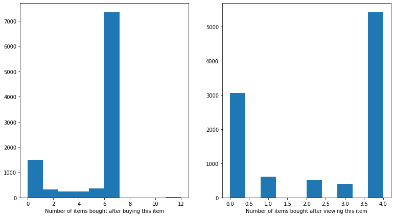

```python
fig, (ax1,ax2) =plt.subplots(1,2,figsize=(13,7))
ax1.hist(product['Number of items bought after buying this item'])
ax1.set_xlabel('Number of items bought after buying this item')
ax2.hist(product['Number of items bought after viewing this item'])
ax2.set_xlabel('Number of items bought after viewing this item')
```

The majority of the number of items bought after buying this item is 6. Similarly, the majority of the number of items purchased after viewing this item is 4. There are just a few outliers. Even though not distributed symmetrically, they only have several values, and the range is small. So the skewness here doesn't affect my prediction.

*Thirdly*, look at the correlation between each variable and the following purchasing quantities. Some are positive, while others are negative. Therefore, I plot the correlation in an ascending order.

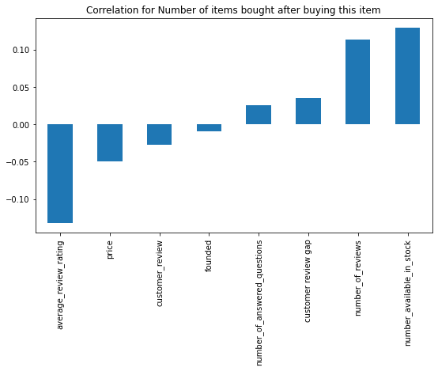

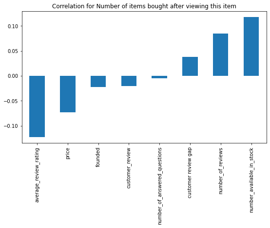

```python
##check the correlation of outcome variable and item features to see their raw linear relationship
quantity_corr=product.corr()[['Number of items bought after buying this item','Number of items bought after viewing this item']].drop(['Number of items bought after buying this item','Number of items bought after viewing this item'])
quantity_corr['Number of items bought after buying this item'].sort_values().plot.bar(title ='Correlation for Number of items bought after buying this item',figsize=(9,5))
plt.show()
quantity_corr['Number of items bought after viewing this item'].sort_values().plot.bar(title ='Correlation for Number of items bought after viewing this item',figsize=(9,5))
```

*Lastly*, use line plots of labels with respect to some features to show their non-linear relationship.

1. show the non-linear relationship of number available in stock with labels using line plots

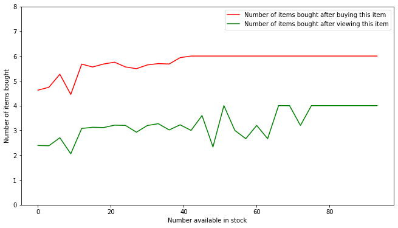

```python
#There are too many observations and highly non-linear relationshp. Therefore, I use the mean of labels for a certain range of number available in stock to smooth the line.
#The following three line codes calculate the average number of items bought for a 4 width interval.
product['number_available_in_stock_1']=round(product['number_available_in_stock']/3)*3
y_1=product.groupby('number_available_in_stock_1')['Number of items bought after buying this item'].mean()
y_2=product.groupby('number_available_in_stock_1')['Number of items bought after viewing this item'].mean()

product=product.drop('number_available_in_stock_1',axis=1)
x_1=pd.Series(y_1.index)
plt.rcParams["figure.figsize"] = (11,6)
plt.plot(x_1, y_1, 'r-')
plt.xlabel('Number available in stock')
plt.ylabel('Number of items bought')
plt.plot(x_1, y_2, 'g-')
plt.ylim(0,8)
plt.legend(["Number of items bought after buying this item", "Number of items bought after viewing this item"])
```

The above figures show that consumers bought more products after buying an item for the same number available in stock compared with that viewing an item. In addition, as "number_available_in_stock" increases, the number of items customers bought increases. But their relationship is not strictly linear. Therefore, the non-linear machine learning algorithm might work well in modeling their relationship.

1. show the non-linear relationship of "average_review_rating" and "customer review gap" with labels using line plots

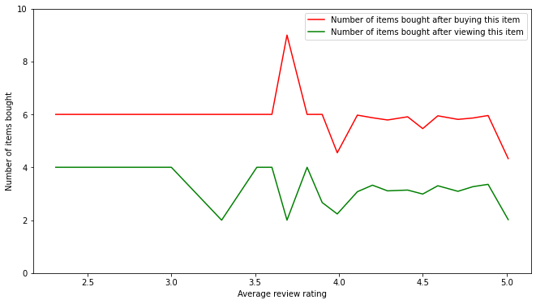

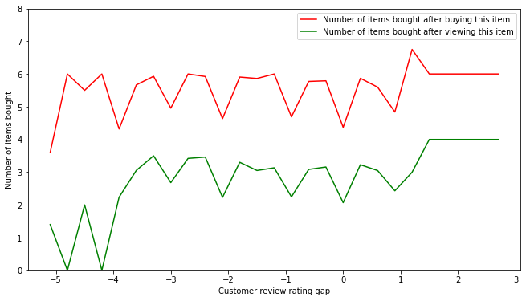

```python
#similar to the previous figure
product['average_review_rating_1']=round(product['average_review_rating']/3,2)*3
y_1=product.groupby('average_review_rating_1')['Number of items bought after buying this item'].mean()
y_2=product.groupby('average_review_rating_1')['Number of items bought after viewing this item'].mean()
product=product.drop('average_review_rating_1',axis=1)
x_1=pd.Series(y_1.index)
plt.rcParams["figure.figsize"] = (11,6)
plt.plot(x_1, y_1, 'r-')
plt.xlabel('Average review rating')
plt.ylabel('Number of items bought')
plt.plot(x_1, y_2, 'g-')
plt.ylim(0,10)
plt.legend(["Number of items bought after buying this item", "Number of items bought after viewing this item"])
plt.show()

product['customer review gap 1']=round(product['customer review gap']/3,1)*3
y_1=product.groupby('customer review gap 1')['Number of items bought after buying this item'].mean()
y_2=product.groupby('customer review gap 1')['Number of items bought after viewing this item'].mean()
product=product.drop('customer review gap 1',axis=1)
x_1=pd.Series(y_1.index)
plt.rcParams["figure.figsize"] = (11,6)
plt.plot(x_1, y_1, 'r-')
plt.xlabel('Customer review rating gap')
plt.ylabel('Number of items bought')
plt.plot(x_1, y_2, 'g-')
plt.ylim(0,8)
plt.legend(["Number of items bought after buying this item", "Number of items bought after viewing this item"])
```

The above figures show that for the same customer review rating, consumers bought more products after buying an item compared with that viewing an item. In addition, we can see as the average review rating exhibits a non-linearly relationship with the number of items bought, especially when the average review rating exceeds 3.5. The same is true for the customer review rating gap. Therefore, the non-linear machine learning algorithm might work well in modeling their relationship.

1. The relationship of term caegory has not be presented in the above analysis. In the following part, I will show the relationship of number of items bought with item catogories to see their non-linear relationship.

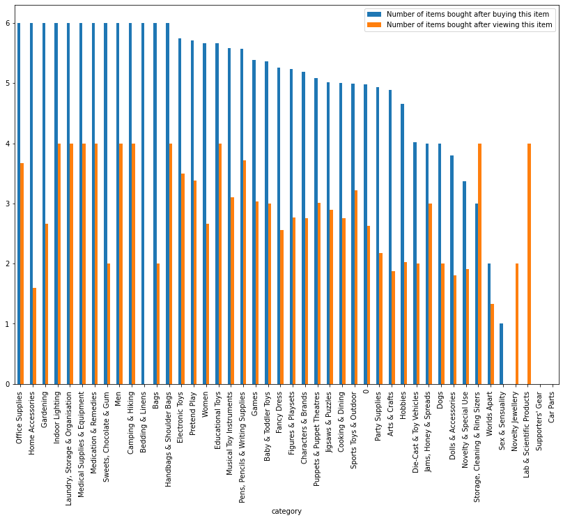

```python
df_1 = product.groupby('category').mean().sort_values('Number of items bought after buying this item',ascending=False)
df_2=df_1[['Number of items bought after buying this item','Number of items bought after viewing this item']]
df_2.plot(kind = 'bar',figsize=(14,10))
```

The above figure shows that there are significant differences in the following purchasing quantities among categories. For example, the average number of items bought after buying this item is 6 for office supplies. However, the average number for novelty jewelry is zero. Therefore, using a set of dummies to measure item categories is expected to have a strong predictive power for following purchasing quantities.

# **Model Fitting and Prediction**

I will train different models to explore my two project questions in this part. To analyze the first question (Do consumer review ratings predict their following purchasing quantity?), I will take the next two steps. Firstly, I will train a linear regression to test whether consumers' review rating matters for predicting the following purchasing quantities. Secondly, I will train a K-nearest neighbor (KNN) model to see whether including the consumer's review rating will affect the prediction score.

Besides, I will explore the second question: Can consumer review ratings and item characteristics predict consumers' following number of purchases well? Firstly, I train a KNN model using and calculating its prediction performance. Next, I train a random forest regression model to calculate its prediction performance. Lastly, based on the performance of those two models, I choose one that achieves the best performance and plots the predicted labels versus actual labels.

```python
#get the features and transform the categorical vaariables into a set of dummies.
X_selected=product.drop(['Number of items bought after buying this item','Number of items bought after viewing this item'],axis=1)
###Transform the categorical variable into dummies.
X=pd.get_dummies(X_selected)
print(X.shape)
X
```

```
(10003, 3118)
```

|  | price | number_available_in_stock | number_of_reviews | number_of_answered_questions | average_review_rating | founded | customer_review | customer review gap | number_available_in_stock_1 | manufacturer_101 | ... | sub_category_3_ Transformers & Decoders | sub_category_3_ Vehicles | sub_category_3_ Wagons | sub_category_3_ Window Stickers | sub_category_3_ Wooden Thomas | sub_category_4_0 | sub_category_4_ Figures | sub_category_4_ Landscape Architecture | sub_category_4_ Road Construction | sub_category_4_ Track Construction |
| --- | --- | --- | --- | --- | --- | --- | --- | --- | --- | --- | --- | --- | --- | --- | --- | --- | --- | --- | --- | --- | --- |
| 0 | 3.42 | 5.000000 | 15.0 | 1.0 | 4.9 | 2005.821429 | 4.0 | -0.9 | 6.0 | 0 | ... | 0 | 0 | 0 | 0 | 0 | 1 | 0 | 0 | 0 | 0 |
| 1 | 16.99 | 7.914095 | 2.0 | 1.0 | 4.5 | 2005.821429 | 4.0 | -0.5 | 9.0 | 0 | ... | 0 | 0 | 0 | 0 | 0 | 1 | 0 | 0 | 0 | 0 |
| 2 | 9.99 | 2.000000 | 17.0 | 2.0 | 3.9 | 1978.000000 | 5.0 | 1.1 | 3.0 | 0 | ... | 0 | 0 | 0 | 0 | 0 | 1 | 0 | 0 | 0 | 0 |
| 3 | 9.99 | 2.000000 | 17.0 | 2.0 | 3.9 | 2005.821429 | 5.0 | 1.1 | 3.0 | 0 | ... | 0 | 0 | 0 | 0 | 0 | 1 | 0 | 0 | 0 | 0 |
| 4 | 9.99 | 2.000000 | 17.0 | 2.0 | 3.9 | 1973.000000 | 5.0 | 1.1 | 3.0 | 0 | ... | 0 | 0 | 0 | 0 | 0 | 1 | 0 | 0 | 0 | 0 |
| ... | ... | ... | ... | ... | ... | ... | ... | ... | ... | ... | ... | ... | ... | ... | ... | ... | ... | ... | ... | ... | ... |
| 10019 | 22.95 | 5.000000 | 3.0 | 3.0 | 5.0 | 2005.821429 | 0.0 | -5.0 | 6.0 | 0 | ... | 0 | 0 | 0 | 0 | 0 | 1 | 0 | 0 | 0 | 0 |
| 10020 | 39.99 | 7.914095 | 1.0 | 3.0 | 4.0 | 2005.821429 | 0.0 | -4.0 | 9.0 | 0 | ... | 0 | 0 | 0 | 0 | 0 | 1 | 0 | 0 | 0 | 0 |
| 10021 | 43.99 | 3.000000 | 1.0 | 3.0 | 5.0 | 2005.821429 | 0.0 | -5.0 | 3.0 | 0 | ... | 0 | 0 | 0 | 0 | 0 | 1 | 0 | 0 | 0 | 0 |
| 10022 | 49.81 | 3.000000 | 1.0 | 3.0 | 5.0 | 2005.821429 | 0.0 | -5.0 | 3.0 | 0 | ... | 0 | 0 | 0 | 0 | 0 | 1 | 0 | 0 | 0 | 0 |
| 10023 | 21.20 | 31.000000 | 11.0 | 3.0 | 4.5 | 2005.821429 | 0.0 | -4.5 | 30.0 | 0 | ... | 0 | 0 | 0 | 0 | 0 | 1 | 0 | 0 | 0 | 0 |

10003 rows × 3118 columns

```python
#Get labels from product data
y1=product['Number of items bought after buying this item']
y2=product['Number of items bought after viewing this item']
```

Split the sample into train datasets and test datasets. This helps us train the model on train datasets and test model's performance on test datasets.

```python
from sklearn.model_selection import train_test_split
from sklearn.ensemble import RandomForestRegressor
X1_train,X1_test,y1_train,y1_test=train_test_split(X,y1,test_size=0.2,random_state=42)
X2_train,X2_test,y2_train,y2_test=train_test_split(X,y2,test_size=0.2,random_state=42)
```

Question 1. Explore the first question:Do consumer's review ratings predict their following purchasing quantity? Firstly, I will train a linear regression to test whether consumer's review rating mattters for predicting following purchasing quantities.

```python
from sklearn.linear_model import LinearRegression
import statsmodels.api as sm
from scipy import stats
#the following code estimate the linear relationship between number of items bought after buying this item and features
X2 = sm.add_constant(X1_train)
est = sm.OLS(y1_train, X2)
est2 = est.fit()
est2.summary()
```

OLS Regression Results

| Dep. Variable: | Number of items bought after buying this item | R-squared: | 0.517 |
| --- | --- | --- | --- |
| Model: | OLS | Adj. R-squared: | 0.294 |
| Method: | Least Squares | F-statistic: | 2.319 |
| Date: | Tue, 13 Dec 2022 | Prob (F-statistic): | 4.80e-146 |
| Time: | 18:13:29 | Log-Likelihood: | -14528. |
| No. Observations: | 8002 | AIC: | 3.412e+04 |
| Df Residuals: | 5471 | BIC: | 5.180e+04 |
| Df Model: | 2530 |  |  |
| Covariance Type: | nonrobust |  |  |

|  | coef | std err | t | P>\|t\| | [0.025 | 0.975] |
| --- | --- | --- | --- | --- | --- | --- |
| const | -0.0008 | 0.025 | -0.034 | 0.973 | -0.050 | 0.048 |
| price | -0.0020 | 0.001 | -2.493 | 0.013 | -0.004 | -0.000 |
| number_available_in_stock | 0.1530 | 0.032 | 4.815 | 0.000 | 0.091 | 0.215 |
| number_of_reviews | 0.0025 | 0.001 | 3.171 | 0.002 | 0.001 | 0.004 |
| number_of_answered_questions | 0.0108 | 0.011 | 0.984 | 0.325 | -0.011 | 0.032 |
| average_review_rating | 0.9975 | 6.208 | 0.161 | 0.872 | -11.173 | 13.168 |
| founded | 0.0024 | 0.001 | 4.639 | 0.000 | 0.001 | 0.003 |
| customer_review | -1.3984 | 6.209 | -0.225 | 0.822 | -13.570 | 10.773 |
| customer review gap | 1.3513 | 6.209 | 0.218 | 0.828 | -10.820 | 13.523 |
| number_available_in_stock_1 | -0.1319 | 0.031 | -4.199 | 0.000 | -0.193 | -0.070 |
| manufacturer_101 | 0.4940 | 1.826 | 0.271 | 0.787 | -3.086 | 4.074 |
| manufacturer_13 | 1.8806 | 1.900 | 0.990 | 0.322 | -1.844 | 5.605 |
| manufacturer_16th Birthday 16th Foil Banner - 9ft | -2.9679 | 1.820 | -1.630 | 0.103 | -6.536 | 0.601 |
| manufacturer_1st birthday | 1.0110 | 1.820 | 0.556 | 0.579 | -2.556 | 4.578 |
| manufacturer_2-in-1 Chess & Draughts | -0.2041 | 1.855 | -0.110 | 0.912 | -3.841 | 3.433 |
| manufacturer_24 Game | 0.6188 | 1.826 | 0.339 | 0.735 | -2.960 | 4.198 |
| manufacturer_4 Pocket Pro Binder Black | 0.2933 | 2.003 | 0.146 | 0.884 | -3.634 | 4.220 |
| manufacturer_45" Sunset Glow Pool | 1.5734 | 1.850 | 0.850 | 0.395 | -2.054 | 5.200 |
| manufacturer_4M | 0.8691 | 1.083 | 0.802 | 0.422 | -1.254 | 2.993 |
| manufacturer_4M Crafty Kids | 1.6023 | 1.325 | 1.209 | 0.227 | -0.996 | 4.200 |
| manufacturer_50Fifty | 2.0373 | 1.299 | 1.568 | 0.117 | -0.510 | 4.585 |
| manufacturer_50th Birthday | 1.2975 | 1.884 | 0.689 | 0.491 | -2.396 | 4.991 |
| manufacturer_60° | -0.0549 | 2.294 | -0.024 | 0.981 | -4.553 | 4.443 |
| manufacturer_8 | 0.5141 | 1.825 | 0.282 | 0.778 | -3.065 | 4.093 |
| manufacturer_80s Material Girl | 1.0179 | 1.874 | 0.543 | 0.587 | -2.657 | 4.693 |
| manufacturer_A B Gee | 0.0443 | 1.067 | 0.042 | 0.967 | -2.047 | 2.135 |
| manufacturer_A Kent & Cleal game | 0.2843 | 0.700 | 0.406 | 0.685 | -1.088 | 1.657 |
| manufacturer_A Nightmare On Elm Street | -0.2127 | 1.855 | -0.115 | 0.909 | -3.849 | 3.424 |
| manufacturer_A Plus | 1.5024 | 1.804 | 0.833 | 0.405 | -2.035 | 5.040 |
| manufacturer_A to Z | 0.7977 | 1.825 | 0.437 | 0.662 | -2.779 | 4.375 |

[output cut: 3089 more lines]

| Omnibus: | 1486.135 | Durbin-Watson: | 2.014 |
| --- | --- | --- | --- |
| Prob(Omnibus): | 0.000 | Jarque-Bera (JB): | 3610.303 |
| Skew: | -1.037 | Prob(JB): | 0.00 |
| Kurtosis: | 5.555 | Cond. No. | 5.62e+21 |

Notes:  
[1] Standard Errors assume that the covariance matrix of the errors is correctly specified.  
[2] The smallest eigenvalue is 1.02e-33. This might indicate that there are  
strong multicollinearity problems or that the design matrix is singular.

```python
#the following code estimate the linear relationship between number of items bought after viewing this item and features
X2 = sm.add_constant(X2_train)
est = sm.OLS(y2_train, X2)
est2 = est.fit()
est2.summary()
```

OLS Regression Results

| Dep. Variable: | Number of items bought after viewing this item | R-squared: | 0.495 |
| --- | --- | --- | --- |
| Model: | OLS | Adj. R-squared: | 0.262 |
| Method: | Least Squares | F-statistic: | 2.123 |
| Date: | Tue, 13 Dec 2022 | Prob (F-statistic): | 5.97e-117 |
| Time: | 18:17:11 | Log-Likelihood: | -13384. |
| No. Observations: | 8002 | AIC: | 3.183e+04 |
| Df Residuals: | 5471 | BIC: | 4.952e+04 |
| Df Model: | 2530 |  |  |
| Covariance Type: | nonrobust |  |  |

|  | coef | std err | t | P>\|t\| | [0.025 | 0.975] |
| --- | --- | --- | --- | --- | --- | --- |
| const | 0.0071 | 0.022 | 0.332 | 0.740 | -0.035 | 0.049 |
| price | -0.0023 | 0.001 | -3.265 | 0.001 | -0.004 | -0.001 |
| number_available_in_stock | 0.1109 | 0.028 | 4.027 | 0.000 | 0.057 | 0.165 |
| number_of_reviews | 0.0005 | 0.001 | 0.760 | 0.447 | -0.001 | 0.002 |
| number_of_answered_questions | 0.0068 | 0.009 | 0.722 | 0.470 | -0.012 | 0.025 |
| average_review_rating | 1.2433 | 5.381 | 0.231 | 0.817 | -9.306 | 11.793 |
| founded | 0.0014 | 0.000 | 3.103 | 0.002 | 0.001 | 0.002 |
| customer_review | -1.4972 | 5.381 | -0.278 | 0.781 | -12.047 | 9.053 |
| customer review gap | 1.4780 | 5.381 | 0.275 | 0.784 | -9.072 | 12.028 |
| number_available_in_stock_1 | -0.0950 | 0.027 | -3.490 | 0.000 | -0.148 | -0.042 |
| manufacturer_101 | 0.8612 | 1.583 | 0.544 | 0.586 | -2.242 | 3.964 |
| manufacturer_13 | 2.7930 | 1.647 | 1.696 | 0.090 | -0.435 | 6.021 |
| manufacturer_16th Birthday 16th Foil Banner - 9ft | -0.1086 | 1.578 | -0.069 | 0.945 | -3.202 | 2.984 |
| manufacturer_1st birthday | -2.1221 | 1.577 | -1.345 | 0.179 | -5.214 | 0.970 |
| manufacturer_2-in-1 Chess & Draughts | 0.3681 | 1.608 | 0.229 | 0.819 | -2.784 | 3.520 |
| manufacturer_24 Game | 0.8737 | 1.582 | 0.552 | 0.581 | -2.228 | 3.976 |
| manufacturer_4 Pocket Pro Binder Black | 0.8639 | 1.736 | 0.498 | 0.619 | -2.540 | 4.268 |
| manufacturer_45" Sunset Glow Pool | 1.1346 | 1.604 | 0.708 | 0.479 | -2.009 | 4.278 |
| manufacturer_4M | 1.6326 | 0.939 | 1.739 | 0.082 | -0.208 | 3.473 |
| manufacturer_4M Crafty Kids | 2.9207 | 1.149 | 2.543 | 0.011 | 0.669 | 5.173 |
| manufacturer_50Fifty | 0.3283 | 1.126 | 0.291 | 0.771 | -1.880 | 2.536 |
| manufacturer_50th Birthday | 2.1281 | 1.633 | 1.303 | 0.193 | -1.073 | 5.330 |
| manufacturer_60° | 0.6726 | 1.989 | 0.338 | 0.735 | -3.226 | 4.571 |
| manufacturer_8 | -2.7107 | 1.582 | -1.713 | 0.087 | -5.813 | 0.391 |
| manufacturer_80s Material Girl | 1.0526 | 1.625 | 0.648 | 0.517 | -2.132 | 4.238 |
| manufacturer_A B Gee | -1.3805 | 0.924 | -1.493 | 0.135 | -3.193 | 0.432 |
| manufacturer_A Kent & Cleal game | 0.7372 | 0.607 | 1.215 | 0.224 | -0.452 | 1.927 |
| manufacturer_A Nightmare On Elm Street | 1.2479 | 1.608 | 0.776 | 0.438 | -1.904 | 4.400 |
| manufacturer_A Plus | -2.1568 | 1.564 | -1.379 | 0.168 | -5.223 | 0.909 |
| manufacturer_A to Z | -2.5727 | 1.582 | -1.627 | 0.104 | -5.673 | 0.528 |

[output cut: 3089 more lines]

| Omnibus: | 160.785 | Durbin-Watson: | 2.000 |
| --- | --- | --- | --- |
| Prob(Omnibus): | 0.000 | Jarque-Bera (JB): | 170.137 |
| Skew: | -0.352 | Prob(JB): | 1.14e-37 |
| Kurtosis: | 3.115 | Cond. No. | 5.62e+21 |

Notes:  
[1] Standard Errors assume that the covariance matrix of the errors is correctly specified.  
[2] The smallest eigenvalue is 1.02e-33. This might indicate that there are  
strong multicollinearity problems or that the design matrix is singular.

Secondly, I will train a K-nearest neighbor model to see whether including the consumer's review rating or not will affect the prediction score. In the following cell, I will train a KNN model using all product features but excluding consumer review indicators.

```python
from sklearn.neighbors import KNeighborsRegressor
from sklearn.metrics import mean_squared_error
#get the features without consumer review and transform the categorical vaariables into a set of dummies.
X_selected_drop_review=product.drop(['Number of items bought after buying this item','Number of items bought after viewing this item','number_of_reviews','average_review_rating','customer_review', 'customer review gap'],axis=1)
#Transform the categorical variable into dummies.
X_drop_review=pd.get_dummies(X_selected_drop_review)
X1_train_drop_review,X1_test_drop_review,y1_train_drop_review,y1_test_drop_review=train_test_split(X_drop_review,y1,test_size=0.2,random_state=42)
X2_train_drop_review,X2_test_drop_review,y2_train_drop_review,y2_test_drop_review=train_test_split(X_drop_review,y2,test_size=0.2,random_state=42)


#Since I only want to test the importance of consumer's review, the key point is to see the model's prediction performace with consumer's review and without consumer's review.
#Therefore,  I set k=10 here
knn_reg=KNeighborsRegressor(n_neighbors=10)
knn_reg.fit(X1_train_drop_review,y1_train_drop_review)
y1_test_pred=knn_reg.predict(X1_test_drop_review)
mse=mean_squared_error(y1_test_drop_review,y1_test_pred)
rmse=np.sqrt(mse)
print(f'The mse of knn model without consumer review for number of items bought after buying this item is {rmse}')
knn_reg.fit(X2_train_drop_review,y2_train_drop_review)
y2_test_pred=knn_reg.predict(X2_test_drop_review)
mse=mean_squared_error(y2_test_drop_review,y2_test_pred)
rmse=np.sqrt(mse)
print(f'The mse of knn model without consumer review for number of items bought after viewing this item is {rmse}')
```

```
The mse of knn model without consumer review for number of items bought after buying this item is 2.06581248166316
The mse of knn model without consumer review for number of items bought after viewing this item is 1.7568527923912503
```

```python
#g cell, I will train a KNN model using all pruduct features, including consumer review indicators.
knn_reg.fit(X1_train,y1_train)
y1_test_pred=knn_reg.predict(X1_test)
mse=mean_squared_error(y1_test,y1_test_pred)
rmse=np.sqrt(mse)
print(f'The mse of knn model with consumer review for number of items bought after buying this item is {rmse}')
knn_reg.fit(X2_train,y2_train)
y2_test_pred=knn_reg.predict(X2_test)
mse=mean_squared_error(y2_test,y2_test_pred)
rmse=np.sqrt(mse)
print(f'The mse of knn model with consumer review for number of items bought after viewing this item is {rmse}')
```

```
The mse of knn model with consumer review for number of items bought after buying this item is 1.9517275372884646
The mse of knn model with consumer review for number of items bought after viewing this item is 1.697886507015309
```

**Question** **2**. I will explore the second question: Can consumer review ratings and item characteristics predict consumers' following number of purchases well? Firstly, I train a KNN model using and calculating its prediction performance.

```python
from sklearn.neighbors import KNeighborsRegressor
from sklearn.metrics import mean_squared_error
from sklearn.model_selection import cross_val_score
RMSE_knn=[]
for k in range(1,100,5):
  knn_reg=KNeighborsRegressor(n_neighbors=k)
  score1=cross_val_score(knn_reg,X1_train,y1_train,cv=3,scoring='neg_mean_squared_error',n_jobs=-1).mean()
  score2=cross_val_score(knn_reg,X2_train,y2_train,cv=3,scoring='neg_mean_squared_error',n_jobs=-1).mean()
  RMSE_knn.append([k,np.sqrt(-score1),np.sqrt(-score2)])
```

```python
RMSE_knn_df=pd.DataFrame(RMSE_knn,columns=['number of neighbors','cross validation rmse for number of items bought after buying','cross validation rmse for number of items bought after viewing'])
print(f'The smallest root mean squared error of knn model for number of items bought after buying this item is {RMSE_knn_df.iloc[:,1].min()}')
print(f'The smallest root mean squared error of knn model for number of items bought after viewing this item is {RMSE_knn_df.iloc[:,2].min()}')
RMSE_knn_df
```

```
The smallest root mean squared error of knn model for number of items bought after buying this item is 1.9408344489769884
The smallest root mean squared error of knn model for number of items bought after viewing this item is 1.676003325882236
```

|  | number of neighbors | cross validation rmse for number of items bought after buying | cross validation rmse for number of items bought after viewing |
| --- | --- | --- | --- |
| 0 | 1 | 2.620864 | 2.245743 |
| 1 | 6 | 2.030041 | 1.724016 |
| 2 | 11 | 1.980025 | 1.692788 |
| 3 | 16 | 1.966941 | 1.683139 |
| 4 | 21 | 1.956641 | 1.676098 |
| 5 | 26 | 1.951605 | 1.676003 |
| 6 | 31 | 1.947791 | 1.676182 |
| 7 | 36 | 1.945609 | 1.676419 |
| 8 | 41 | 1.943214 | 1.676207 |
| 9 | 46 | 1.943080 | 1.676556 |
| 10 | 51 | 1.940834 | 1.676821 |
| 11 | 56 | 1.941867 | 1.676084 |
| 12 | 61 | 1.942896 | 1.677170 |
| 13 | 66 | 1.942697 | 1.678522 |
| 14 | 71 | 1.944429 | 1.679600 |
| 15 | 76 | 1.946953 | 1.681408 |
| 16 | 81 | 1.947928 | 1.681781 |
| 17 | 86 | 1.948680 | 1.682160 |
| 18 | 91 | 1.950075 | 1.683856 |
| 19 | 96 | 1.952045 | 1.684951 |

Based on previous results, k=51 returns the smallest cross-validation rmse. Therefore, for the following cell, set k=51 and train the KNN model on the whole training dataset. Then calculate the test rmse for the test datasets.

```python
index_min_rmse=RMSE_knn_df.iloc[:,1].argmin()
k=RMSE_knn_df.iloc[index_min_rmse,0]
knn_reg=KNeighborsRegressor(n_neighbors=k)
knn_reg.fit(X1_train,y1_train)
y1_test_pred=knn_reg.predict(X1_test)
rmse=np.sqrt(mean_squared_error(y1_test,y1_test_pred))
print(f'The test rmse of knn model with consumer review for number of items bought after buying this item is {rmse}')
knn_reg.fit(X2_train,y2_train)
y2_test_pred=knn_reg.predict(X2_test)
rmse=np.sqrt(mean_squared_error(y2_test,y2_test_pred))
print(f'The test rmse of knn model with consumer review for number of items bought after viewing this item is {rmse}')
```

[output not shown]

Next, I train a random forest regression model to calculate its cross-validation performance.

```python
RMSE_tree=[]
n_estimators=[5,10,20,50,100]
max_depths=[1,5,10,50,100]
for n in n_estimators:
  for d in max_depths:
    rnd_reg=RandomForestRegressor(n_estimators=n,max_depth=d,random_state=42,n_jobs=-1)
    score1=cross_val_score(rnd_reg,X1_train,y1_train,cv=3,scoring='neg_mean_squared_error').mean()
    score2=cross_val_score(rnd_reg,X2_train,y2_train,cv=3,scoring='neg_mean_squared_error').mean()
    RMSE_tree.append([n,d,np.sqrt(-score1),np.sqrt(-score2)])
```

```python
RMSE_tree_df=pd.DataFrame(RMSE_tree,columns=['number of estimators','maximum depths','cross validation rmse for number of items bought after buying this item','cross validation rmse for number of items bought after viewing this item'])
print(f'The smallest root mean squared error of random forest model for number of items bought after buying this item is {RMSE_tree_df.iloc[:,2].min()}')
print(f'The smallest root mean squared error of random forest for number of items bought after viewing this item is {RMSE_tree_df.iloc[:,3].min()}')
RMSE_tree_df
```

```
The smallest root mean squared error of random forest model for number of items bought after buying this item is 1.8586859283405264
The smallest root mean squared error of random forest for number of items bought after viewing this item is 1.573818887148256
```

|  | number of estimators | maximum depths | cross validation rmse for number of items bought after buying this item | cross validation rmse for number of items bought after viewing this item |
| --- | --- | --- | --- | --- |
| 0 | 5 | 1 | 1.961887 | 1.690989 |
| 1 | 5 | 5 | 1.877692 | 1.616078 |
| 2 | 5 | 10 | 1.884838 | 1.611063 |
| 3 | 5 | 50 | 2.021582 | 1.706025 |
| 4 | 5 | 100 | 2.049856 | 1.720523 |
| 5 | 10 | 1 | 1.961686 | 1.690813 |
| 6 | 10 | 5 | 1.873247 | 1.609704 |
| 7 | 10 | 10 | 1.870263 | 1.591478 |
| 8 | 10 | 50 | 1.983212 | 1.651405 |
| 9 | 10 | 100 | 2.008818 | 1.665355 |
| 10 | 20 | 1 | 1.960646 | 1.691009 |
| 11 | 20 | 5 | 1.871827 | 1.605079 |
| 12 | 20 | 10 | 1.866740 | 1.583181 |
| 13 | 20 | 50 | 1.962978 | 1.624367 |
| 14 | 20 | 100 | 1.988037 | 1.634918 |
| 15 | 50 | 1 | 1.959849 | 1.690548 |
| 16 | 50 | 5 | 1.870955 | 1.602865 |
| 17 | 50 | 10 | 1.860800 | 1.577872 |
| 18 | 50 | 50 | 1.940269 | 1.611716 |
| 19 | 50 | 100 | 1.965879 | 1.621264 |
| 20 | 100 | 1 | 1.959811 | 1.690691 |
| 21 | 100 | 5 | 1.869788 | 1.602060 |
| 22 | 100 | 10 | 1.858686 | 1.573819 |
| 23 | 100 | 50 | 1.938411 | 1.604537 |
| 24 | 100 | 100 | 1.962044 | 1.613706 |

Based on previous results, n_estimators=100 and max_depth=10 return the smallest cross-validation rmse. Therefore, for the following cell, set n_estimators=100 and max_depth=10 and train the random forest model on the whole training dataset. Then calculate the test rmse for the test datasets.

```python
index_min_rmse=RMSE_tree_df.iloc[:,2].argmin()
n=RMSE_tree_df.iloc[index_min_rmse,0]
d=RMSE_tree_df.iloc[index_min_rmse,1]
rnd_reg=RandomForestRegressor(n_estimators=n,max_depth=d,random_state=42,n_jobs=-1)
rnd_reg.fit(X1_train,y1_train)
y1_test_pred=rnd_reg.predict(X1_test)
rmse=np.sqrt(mean_squared_error(y1_test,y1_test_pred))
print(f'The test rmse of random forest model with consumer review for number of items bought after buying this item is {rmse}')
rnd_reg.fit(X2_train,y2_train)
y2_test_pred=rnd_reg.predict(X2_test)
rmse=np.sqrt(mean_squared_error(y2_test,y2_test_pred))
print(f'The test rmse of random forest model with consumer review for number of items bought after viewing this item is {rmse}')
```

```
The test rmse of random forest model with consumer review for number of items bought after buying this item is 1.7924393033729449
The test rmse of random forest model with consumer review for number of items bought after viewing this item is 1.5625982325557126
```

Lastly, based on the performance of those two models, the test rmse of the random forest model is smaller. Therefore, I chose the random forest model as the training and prediction model and plotted the predicted labels versus actual labels.

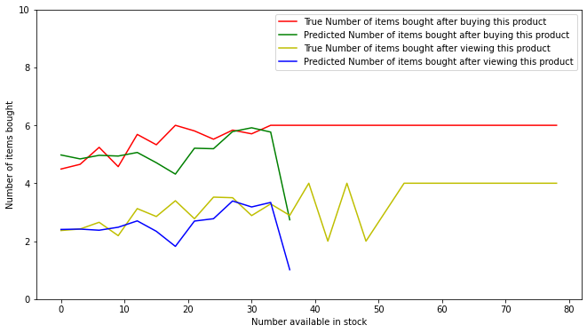

```python
data_new=pd.DataFrame(X1_test,columns=X1_test.columns,index=y1_test.index)
data_new['y1_test']=y1_test
data_new['y1_test_pred']=pd.Series(y1_test_pred)
data_new['y2_test']=y2_test
data_new['y2_test_pred']=pd.Series(y2_test_pred)

data_new['number_available_in_stock_1']=round(data_new['number_available_in_stock']/3)*3
y_1=data_new.groupby('number_available_in_stock_1')['y1_test'].mean()
y_2=data_new.groupby('number_available_in_stock_1')['y1_test_pred'].mean()
y_3=data_new.groupby('number_available_in_stock_1')['y2_test'].mean()
y_4=data_new.groupby('number_available_in_stock_1')['y2_test_pred'].mean()

x_1=pd.Series(y_1.index)
plt.rcParams["figure.figsize"] = (11,6)
plt.plot(x_1, y_1, 'r-')
plt.plot(x_1, y_2, 'g-')
plt.plot(x_1, y_3, 'y-')
plt.plot(x_1, y_4, 'b-')
plt.xlabel('Number available in stock')
plt.ylabel('Number of items bought')
plt.ylim(0,10)
plt.legend(["True Number of items bought after buying this product", "Predicted Number of items bought after buying this product","True Number of items bought after viewing this product", "Predicted Number of items bought after viewing this product"])
```

The above figure plots the true number of items bought versus the predicted amounts of the item bought. Red and green lines represent the number of items bought after purchasing this product. Yellow and blue lines represent the number of items bought after viewing this product. The average root means squared errors are 1.79 and 1.56, respectively. The predictions are ok when the number available is smaller than 30. However, the results could be better when the number available is larger than 35. One possible reason is the consumer's future purchasing behaviors are so complex. Future economic conditions and preferences may influence it, and many factors that my model needs to capture. More indicators, especially consumer characteristics, can be collected to achieve better prediction.

# **Conlusions**

This project mainly deals with two questions for consumers' future purchasing behaviors.

The second one is: Can consumer review ratings and item characteristics predict consumers' following number of purchases well? To better predict the consumers' following number of purchases, I use the cross-validation method to choose the best parameters of the K-nearest neighborhood model and random forest model. After getting the best parameter, I calculate each model's prediction rooted mean squared errors. The rooted mean squared error for the K-nearest neighborhood model is 1.8973387681505385 for the number of items bought after buying this product and 1.664352490838144 for the number of items purchased after viewing this product. The rooted mean squared error for the random forest model is 1.7924393033729449 for the number of items bought after buying this product and 1.5625982325557126 for the number of items purchased after viewing this product. Generally, the rooted mean squared errors for the random forest model are smaller than the K-nearest neighborhood model. Therefore, I choose the random forest model as my prediction model and predict the future purchasing quantities bought. The prediction results are ok but could be better. One possible reason is the consumer's future purchasing behaviors are so complex. Future economic conditions and preferences may influence it, and many factors that my model needs to capture. More indicators, especially consumer characteristics, can be collected to achieve better prediction.

Here are some links that are related to this project. Amazon fashion data are an important dataset in product recommendation. The first link tries to predict outfit compatibility and retrieve complementary items from the set dataset I use. The second is to develop a system to recommend product size fits {Small, Fit, Large} to customers. I hope this tutorial is helpful for understanding consumer behaviors.

Link 1: https://www.amazon.science/publications/outfit-transformer-outfit-representations-for-fashion-recommendation

Link 2: https://www.amazon.science/publications/recommending-product-sizes-to-customers

```python
from google.colab import drive
drive.mount('/content/drive')
!git pull
```

```
fatal: not a git repository (or any of the parent directories): .git
```

```python
%%shell
jupyter nbconvert --to html 'DS project Final.ipynb'
```

[output not shown]

[output cut: 107 more lines]

[output not shown]

[output not shown]